# R Notebook

```r
knitr::opts_chunk$set(fig.width=12, fig.height=8, fig.path='figs/',
                      echo=FALSE, warning=FALSE, message=FALSE)
```

# Introduction to notebook

Here is a R notebook file where I think it will be the best place to summarise and keep trck of the analysis. Those notebooks are similar to iPython notebook but are based on [R Markdown](http://rmarkdown.rstudio.com). See the link for anybody not familiar with it.

I think the best will be to write short R scripts inside the “scripts” folder. Once functionalities work in those scripts we can summarise the progress in this notebook. That way we will manage to keep good track of what’s been done and what still needs to be done.

When you save this Rmarkdown, an html version of the notebook will automatically be created, which you can view in your web browser. By the end of the analysis we should have a near finished report already that we can then export to pdf using Pandoc and other tools like rticles.

The working directory should automatically be set to where this notebook is placed, so there is no need to change it. Make sure you run the latest Rstudio, the extracted data is in the “data” folder, open the R project using the.Rproj file and all should be set to work.

Also, for those who may not know, Rstudio has a fancy git/github that is really handy.

## Notebook example

This is an Notebook. When you execute code within the notebook, the results appear beneath the code.

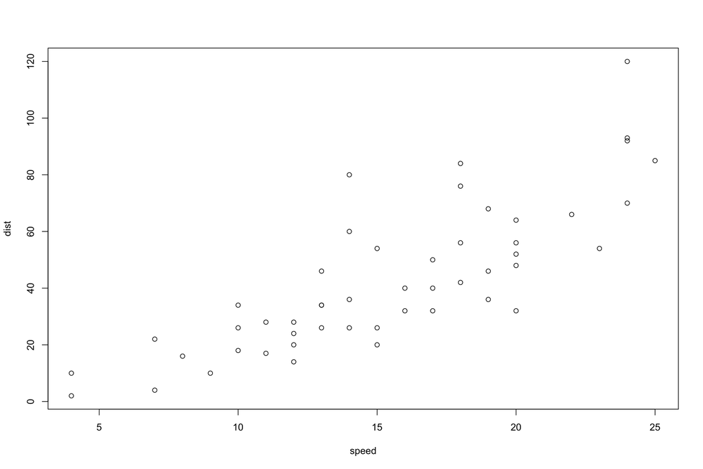

```
## [1] 0.8813914
```

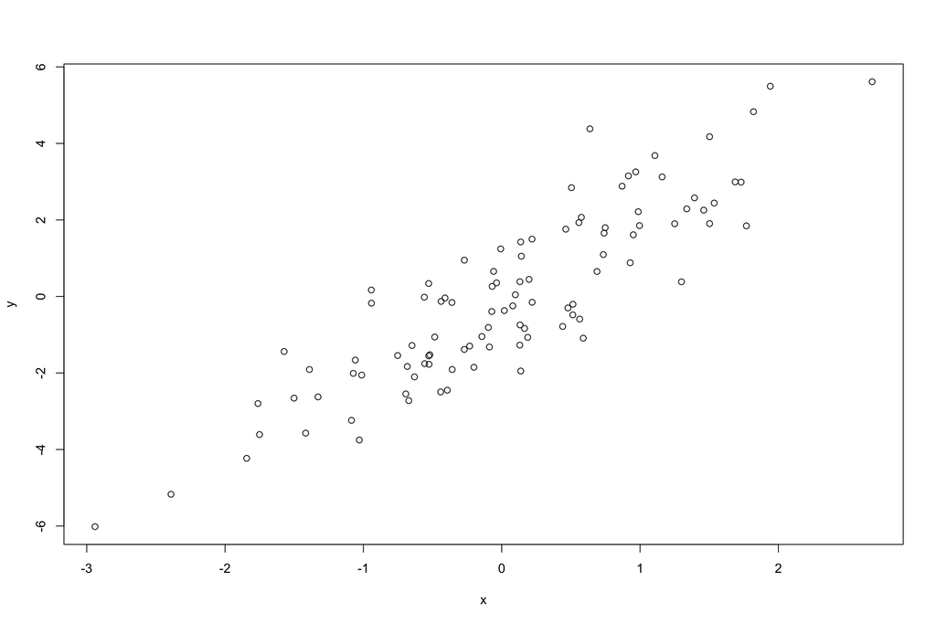